# L05 — Multi-Sample Integration

## Where this lecture fits

- Previous: Lec 04 — Reference-based Annotation
- **You are here:** Lec 05 — *aligning shared cell-type structure across samples without erasing biology*
- Next: Lec 06 — DESeq2: Bulk Fundamentals + Pseudobulk DE
- **Companion tutorial:** Tutorial 05 — Two-Sample Integration
- **Companion book chapter:** Chapter 5 — Multi-Sample Integration

## Goals of this lecture

- Recognize when integration is needed by inspecting the unintegrated UMAP / cluster mix
- Compare integration tools (Harmony, Seurat anchors, scVI, fastMNN) by what they assume
- Read the Harmony 4-step iterative algorithm; read the Seurat anchor + L2 + MNN scoring algorithm
- Diagnose **over-correction** vs **under-correction** with three complementary checks
- Defend the choice of integration method in a methods section

**Note**

**Mental model.**

- Multiple samples / batches / donors of the same biology should produce overlapping clusters of the same cell types.
- If they don’t — if every sample becomes its own island on the UMAP — the technical axis is dominating PC space.
- Integration warps the embedding to move shared cell types together while leaving genuine biological differences in place.

## When to integrate

[figure not shown]

- Multiple samples / batches / donors → the same cell type can split into per-sample clusters
- Integration aligns shared cell types while preserving real biological differences
- **Diagnostic:** color a UMAP by sample. If cell types co-cluster across samples, you don’t need integration. If each sample forms its own island, you do.

## Tools to integrate

| Tool | Ecosystem | Approach |
| --- | --- | --- |
| **Harmony** | R / Py | Iterative soft-clustering in PC space |
| **Seurat CCA / RPCA** | R | Anchor-based cross-sample matching |
| **scVI / scANVI** | Python | Variational autoencoder |
| **BBKNN** | Python | Batch-balanced k-NN graph |
| **MNN / fastMNN** | R / Py | Mutual nearest neighbors |

**Tip**

**Rule of thumb:**

- try a simple method (Harmony) first; move to scVI/scANVI for very large or heterogeneous atlases.
- The workshop’s Tutorial 05 walks Harmony and Seurat anchors on the `ifnb` dataset (CTRL vs IFN-β-stimulated PBMCs) — the canonical small two-sample integration case.
- For a complementary, notebook-driven walkthrough see also the [scNotebooks](https://integrativebioinformatics.github.io/scNotebooks/) integration chapter.

**Warning**

**Over-integration is real.**

- If you push integration too hard, real biological differences (e.g. tumor vs. normal) get squashed away with the batch effect.
- Always plot *both* batch and a known biological covariate after integration to confirm only the unwanted axis was removed.

## Integration strategies — visual guide

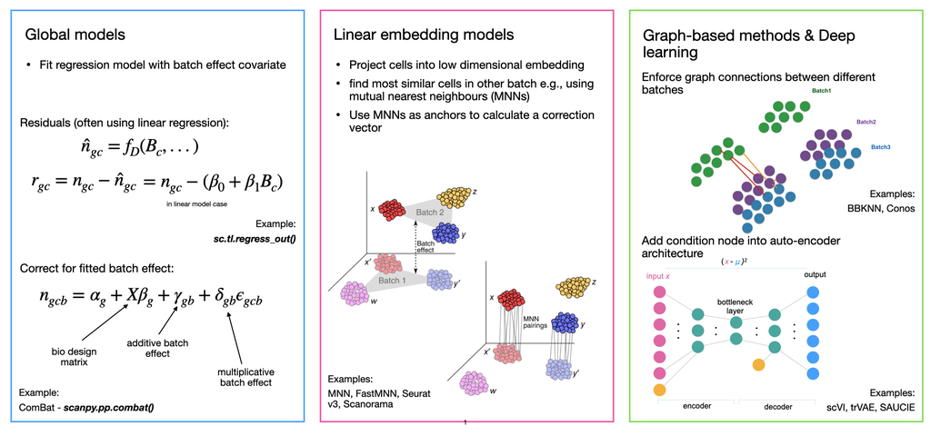

## Seurat CCA integration

[figure not shown]

- Project both samples by **canonical correlation analysis (CCA)** + L2 normalization into a shared low-rank space
- Find pairs of cells that are **mutual nearest neighbours** across the two samples — these are the **anchors**
- **Score** each anchor by how well its local neighbourhoods agree across the two samples
- Apply the anchor-derived correction to bring matching cell types into register

## Harmony integration

[figure not shown]

- Operates in **PC space** after a normal `RunPCA()` — no extra tooling above the standard workflow
- Iterates four steps until convergence: (a) soft-cluster cells with a batch-diversity penalty, (b) compute a global centroid and per-batch centroids per cluster, (c) compute correction factors that pull each per-batch centroid toward the global one, (d) shift each cell using its soft-cluster-weighted correction
- Output is a `harmony` reduction that drops in for `pca` in `FindNeighbors` and `RunUMAP`

## What integration looks like — before vs after

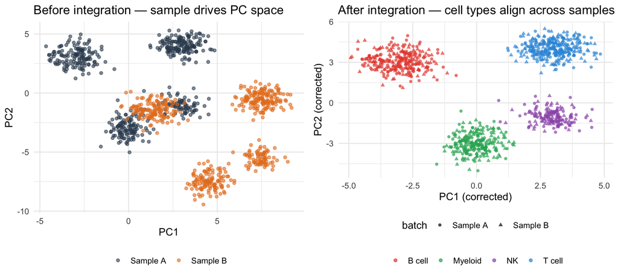

## What integration looks like — before vs after

- **Left:** raw PCA — the biggest axis is *which sample the cell came from*, not *what cell type it is*. Each sample looks like its own island.
- **Right:** after integration (Harmony / FastMNN / scVI / …) — cell types align across samples, and the four populations are now distinguishable on PC1/PC2.
- **Diagnostic check:** colour the post-integration UMAP by batch. If batches mix within each cluster you’re done. If a cluster is still single-batch, either there’s residual batch effect (push integration harder) **or** that population truly only exists in one sample (don’t push, you’ll erase real biology).

**Warning**

The “after” panel above is a cartoon. Real integration *warps* the embedding non-rigidly — that’s what makes it powerful and what makes over-integration dangerous. Always sanity-check with both batch and a known biological covariate.

## Diagnosing over- and under-correction

Three diagnostics, all of which appear in Tutorial 05:

1. **Color the post-integration UMAP by sample.** Cells from each sample should interleave within every cluster. Clusters that remain mostly one sample are either (a) under-corrected or (b) genuinely sample-specific biology (e.g. an activated state present only after stimulation).
2. **Color it by a *biological* covariate.** Cell-type labels (or reference-mapped predictions) should occupy single regions. If a cell type fragments into multiple clusters, integration is leaving residual sample structure.
3. **Score a known biological signal at the cell level and check it survives.** For `ifnb`, score each cell on a panel of interferon-stimulated genes (`ISG15`, `IFI6`, `MX1`, …) and confirm STIM cells still score higher than CTRL cells *within the same cluster*. If integration has flattened that gap, you’ve over-corrected.

These three checks generalize to any batch-integrated dataset. The third is particularly important and easy to forget.

## Quantifying integration: mixing metrics

The three checks above are qualitative. Two common **numerical** scores:

- **iLISI / LISI** (Local Inverse Simpson’s Index)
  - within each cell’s neighbourhood, how many **batches** are represented.
  - High iLISI = batches well mixed. Pair it with **cLISI** (cell-type LISI), which should stay **low** (each neighbourhood is one cell type).
  - Good integration = **high iLISI *and* low cLISI**.
- **kBET** — tests whether the batch composition of local neighbourhoods matches the global composition (a rejection rate; lower = better mixed).

**Warning**

**A mixing metric alone can be gamed by over-correction**

- blend distinct cell types and iLISI looks great.
- Always read a mixing score **together** with a biology-preservation check (cLISI, or the ISG-score gap on the next slides), never one alone.

**Tip**

**This is the most important diagnostic and the one most often skipped.** Always run a known biological signal through the post-integration object and confirm the signal survives. Pretty UMAPs are not the same as preserved biology.

# Recap & what’s next

## What to remember from Lecture 05

- **Integration** is *always* an editorial choice — pick the simplest method that works, then check you didn’t over-correct
- **Harmony** corrects in PC space iteratively; **Seurat anchors** finds mutual nearest neighbours after CCA
- The over-correction check that matters: a **known biological signal** (e.g. ISG score) should still differ between conditions *within* the same cluster after integration
- Always plot the post-integration UMAP coloured by **batch** AND by **biology** — both dimensions